# R2 vs rmse

### R2 vs MSE

Para comparar modelos de regresión la mejor opción es controlar el error, es decir, las diferencias entre los valores reales y las predicciones.

r2 no es una medida del error sino de la varianza de la variable real que explican las variables independientes. Es un buen coeficiente a tener en cuenta además del error, pero a la hora de decidir si un modelo es mejor que otro, es preferible utilizar el error.

En este ejemplo vamos a ver cómo un modelo, al duplicar el número de muestras con cierto sentido, mantiene el error prácticamente igual mientras que el r2 se dispara. Este es uno de los problemas principales del r2, que es muy sensible al número de datos.

La fórmula del r2 es:

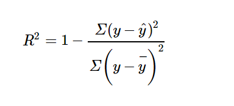

Si os fijáis en la expresión, el numerador controla el error cometido entre predicciones y valores reales mientras que el denominador proporcionaría el error que se comete si todos los datos se estimaran por la media. Si el error cometido es mayor que el resultante del modelo más simple de ajustar por la media, tendremos un cociente superior a 1 y un r2 negativo.

Aquí se ve bien qué quiere decir lo de "varianza explicada"

```python
import numpy as np
import pandas as pd
import matplotlib.pyplot as plt
from sklearn.metrics import r2_score
from sklearn.metrics import mean_squared_error as mse
from sklearn.linear_model import LinearRegression
from math import sqrt
plt.style.use("ggplot")
np.random.seed(0)
```

Generamos una recta con ruido asociado a una normal 0,20:

```python
X=np.arange(1,100,1).reshape(-1,1)
Y=np.array([[x+np.random.normal(0,20) for x in np.arange(1,100,1)]]).reshape(-1,1)
```

Lo metemos en un df:

```python
df_pd=pd.DataFrame(np.concatenate((X,Y),axis=1),columns=["X","Y"])
```

```python
df_pd.head()
```

|  | X | Y |
| --- | --- | --- |
| 0 | 1.0 | 36.281047 |
| 1 | 2.0 | 10.003144 |
| 2 | 3.0 | 22.574760 |
| 3 | 4.0 | 48.817864 |
| 4 | 5.0 | 42.351160 |

Lo vemos en un gráfico:

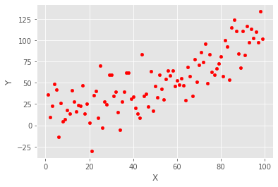

```python
df_pd.plot(kind="scatter",x="X",y="Y",c="red")
pass
```

Vamos a crear un modelo sencillo y lo ajustamos a todo el dataset:

```python
ls = LinearRegression(fit_intercept=True)
```

```python
ls.fit(X=df_pd["X"].values.reshape(-1,1),y=df_pd["Y"].values.reshape(-1,1))
```

```
LinearRegression()
```

Calculamos en primer lugar el r2:

```python
ls.score(X=df_pd["X"].values.reshape(-1,1),y=df_pd["Y"].values.reshape(-1,1))
```

```
0.636702144041218
```

Y ahora el rmse:

```python
error=sqrt(mse(ls.predict(df_pd["X"].values.reshape(-1,1)),df_pd["Y"].values.reshape(-1,1)))
print(error)
```

```
20.15899160361789
```

Graficamos la recta resultante:

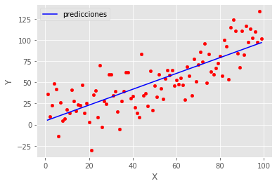

```python
df_pd["predicciones"]=ls.predict(df_pd["X"].values.reshape(-1,1))
fig1=df_pd.plot(kind="line",x="X",y="predicciones",c="blue")
df_pd.plot(kind="scatter",x="X",y="Y",c="red",ax=fig1)
pass
```

Ahora vamos a crear un nuevo df que de 0 a 100 toma los mismos valores que el anterior y de 200 a 300, cada valor es el resultado de sumarle 200 al valor de 0 a 100. Es decir, la imagen de 201 es la imagen de 1 sumándole 200, la de 220 es la de 20 sumándole 200, etc...

```python
X2=np.concatenate((df_pd["X"].values,df_pd["X"].values+200))
Y2=np.concatenate((df_pd["Y"].values,df_pd["Y"].values+200))
```

```python
print(Y2[:10])
print(Y2[99:111])
```

```
[ 36.28104692  10.00314417  22.57475968  48.81786398  42.3511598
 -13.5455576   26.00176835   4.97285583   6.93562296  18.21197004]
[236.28104692 210.00314417 222.57475968 248.81786398 242.3511598
 186.4544424  226.00176835 204.97285583 206.93562296 218.21197004
 213.88087142 241.08547014]
```

```python
df_pd2=pd.DataFrame(np.concatenate((X2.reshape(-1,1),Y2.reshape(-1,1)),axis=1),columns=["X","Y"])
df_pd2.head()
```

|  | X | Y |
| --- | --- | --- |
| 0 | 1.0 | 36.281047 |
| 1 | 2.0 | 10.003144 |
| 2 | 3.0 | 22.574760 |
| 3 | 4.0 | 48.817864 |
| 4 | 5.0 | 42.351160 |

Utilizamos el mismo modelo que antes, ya entrenado, para hacer las predicciones en el nuevo df. Lógicamente, las predicciones en los 100 primeros valores son los mismos que antes, dado que las x son idénticas.

Además, graficamos los nuevos puntos y la recta:

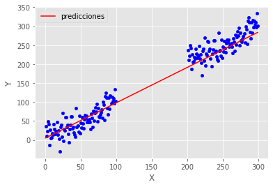

```python
df_pd2["predicciones"]=ls.predict(df_pd2["X"].values.reshape(-1,1))
fig1=df_pd2.plot(kind="line",x="X",y="predicciones",c="red")


df_pd2.plot(kind="scatter",x="X",y="Y",c="blue",ax=fig1)
```

Ahora calculamos el r2 y vemos que se dispara:

```python
ls.score(X=df_pd2["X"].values.reshape(-1,1),y=df_pd2["Y"].values.reshape(-1,1))
```

```
0.955581886605749
```

En cambio, el error medio prácticamente no cambia:

```python
error=sqrt(mse(ls.predict(df_pd2["X"].values.reshape(-1,1)),df_pd2["Y"].values.reshape(-1,1)))
print(error)
```

```
22.223123785653808
```